# Practical 5: Generalized linear models

Author

Benjamin Rosenbaum

We learn how to use some classic GLMs, and a distributional model. We focus on prior specifications and appropriate posterior predictive checks, including the DHARMa package. Sometimes we have to apply ggplot tricks for good conditional effects plots.

**General disclaimer: Never use LOOIC / WAIC / AIC / BIC / DIC for comparing models for continuous responses (Normal, Lognormal, Gamma, Beta, …) to models for discrete responses (Binomial, Poisson, Negative Binomial, …)**

Continuous distributions are based on probability density functions, while discrete distributions have probability mass functions, which you can’t compare.

```r
rm(list=ls())
library("brms")
library("ggplot2")
library("arm")
library("emmeans")
library("performance")
library("Data4Ecologists")
library("cowplot")
library("DHARMa.helpers")
try(dev.off())
```

# Count variables

## Poisson

We start with a simple comparison of 2 group means (frequentists would use a t-test), but the response are counts (number of slugs found per plot, 2 field types, from Data4Ecologists package).

Deterministic part: $\mu=\mu(field)$ –> $\mu_1$ or $\mu_2$  
Stochastic part: $slugs \sim \text{Poisson}(\mu)$

No log-link is used for this simple model, just “identity link”.

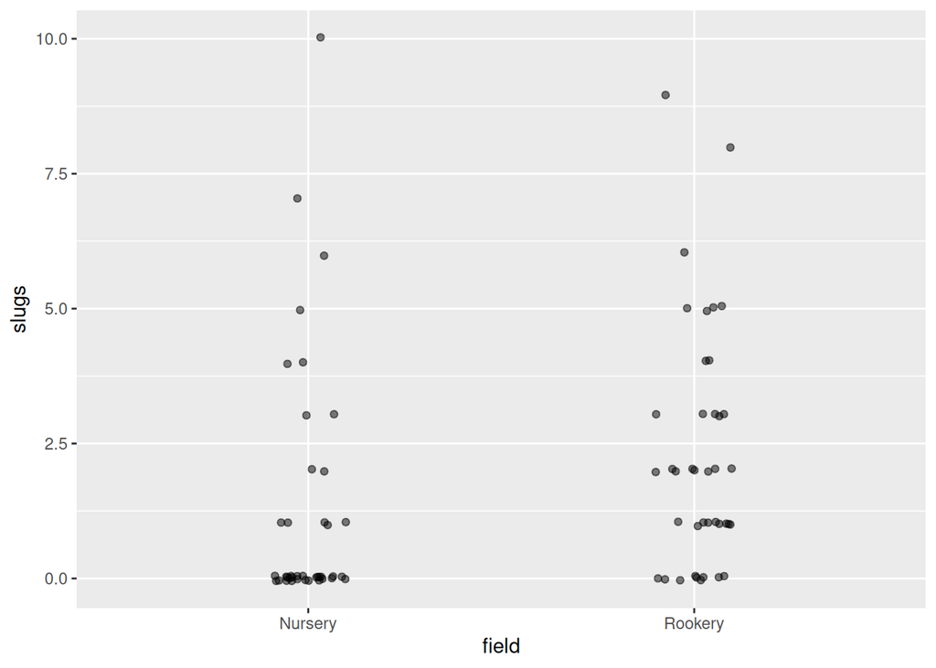

```r
data(slugs)
ggplot(slugs, aes(field, slugs)) +
  geom_jitter(alpha=0.5, width=0.1, height=0.05)
```

It’s always good to check brms default priors in a GLM:

```r
default_prior(slugs ~ field,
              family = poisson(link=identity),
              data = slugs)
```

```
                prior     class         coef group resp dpar nlpar lb ub tag       source
               (flat)         b                                                   default
               (flat)         b fieldRookery                                 (vectorized)
 student_t(3, 1, 2.5) Intercept                                                   default
```

We provide a vague prior for effect (difference in means, dummy-coded) and ensure that the intercept is positive with lower boundary (`lb=0`)

```r
fit.slugs = brm(slugs ~ field,
                family = poisson(link=identity),
                prior =
                  prior(normal(0,2), class=b) +
                  prior(student_t(3, 1, 2.5), class=Intercept, lb=0),
                data = slugs)
```

Check convergence

```r
summary(fit.slugs, prior=TRUE)
```

```
 Family: poisson
  Links: mu = identity
Formula: slugs ~ field
   Data: slugs (Number of observations: 80)
  Draws: 4 chains, each with iter = 2000; warmup = 1000; thin = 1;
         total post-warmup draws = 4000

Priors:
b ~ normal(0, 2)
<lower=0> Intercept ~ student_t(3, 1, 2.5)

Regression Coefficients:
             Estimate Est.Error l-95% CI u-95% CI Rhat Bulk_ESS Tail_ESS
Intercept        1.31      0.18     0.97     1.69 1.00     3585     2535
fieldRookery     0.98      0.29     0.41     1.56 1.00     2438     2311

Draws were sampled using sampling(NUTS). For each parameter, Bulk_ESS
and Tail_ESS are effective sample size measures, and Rhat is the potential
scale reduction factor on split chains (at convergence, Rhat = 1).
```

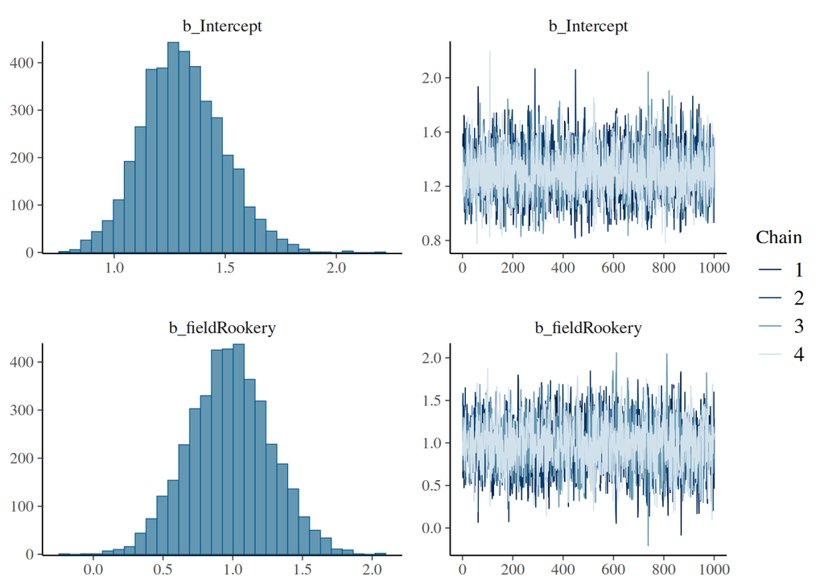

```r
plot(fit.slugs)
```

Posterior predictions

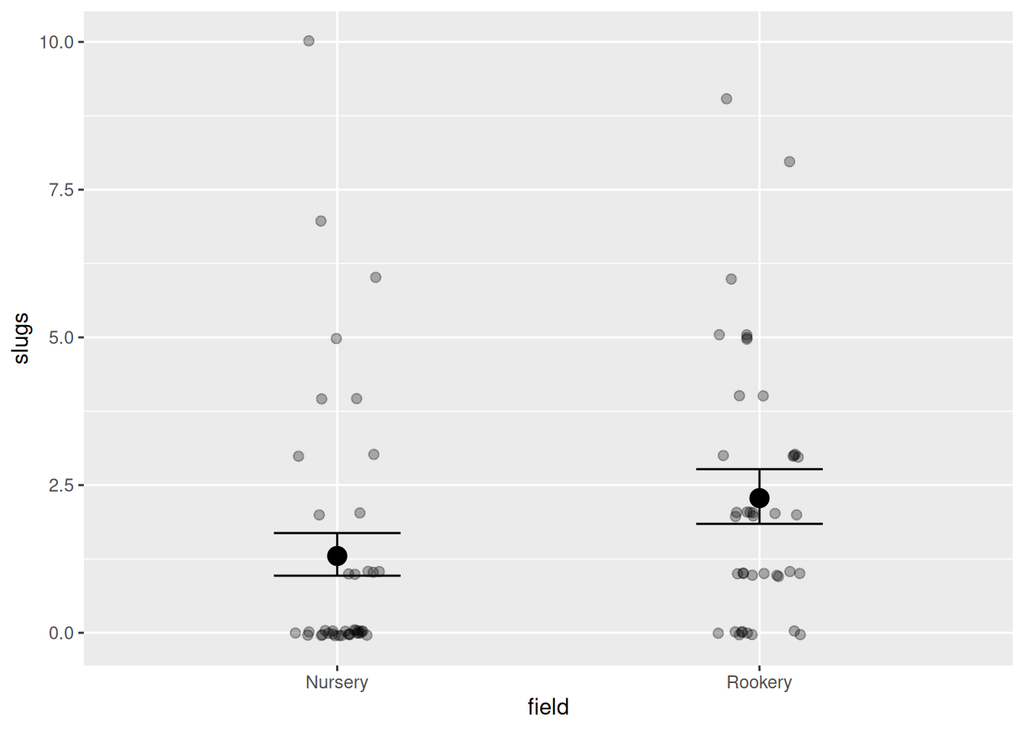

```r
plot(conditional_effects(fit.slugs),
     points=T,
     point_args=list(alpha=0.3, width=0.1, height=0.05)
)
```

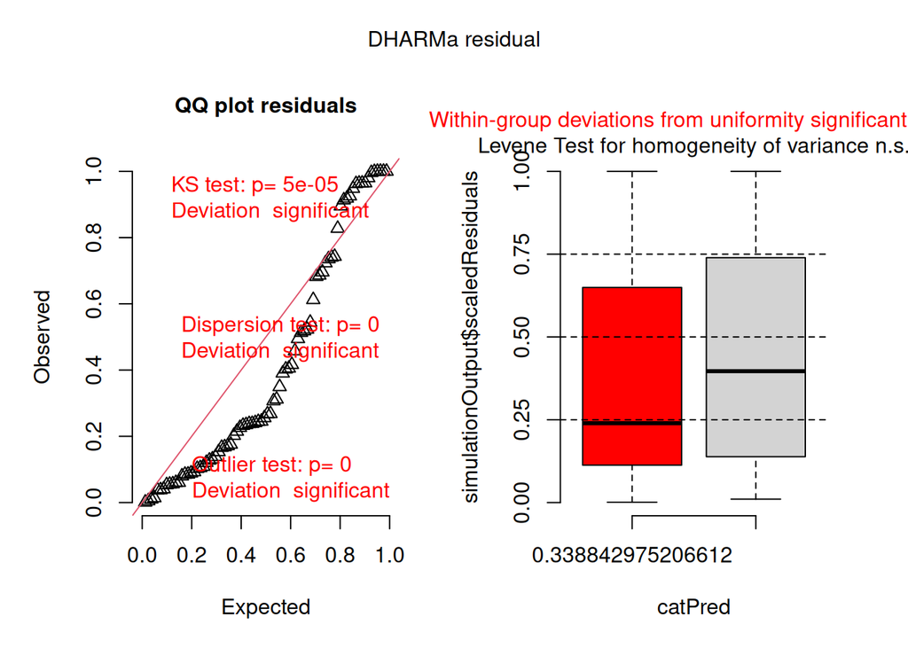

```r
dh_check_brms(fit.slugs) # DHARMa
```

The Poisson distribution often can be too strict, since it does not have a scale parameter and variance is assumed to be identical to the mean. Here, the DHARMa package detects (1) deviation from the Poisson distribution assumption, an therefore (2) overdispersion and (3) outliers. We now try a more appropriate distribution.

## Negative Binomial

Negative Binomial = overdispersed Poisson

An additional precision parameter called `shape` ($\tau$ in the lecture) controls dispersion: variance $\sigma^2=\mu/\tau$. For large $\tau$, we get the Poisson, for small $tau$ the Negative Binomial is an overdispersed Poisson.

It is classically specified by `family=negbinomial()`, but since the identity link is not a standard choice we have to “convince” brms by using `family=brmsfamily("negbinomial, )"`.

```r
default_prior(slugs ~ field,
              family = brmsfamily("negbinomial", link="identity"),
              data = slugs)
```

```
                prior     class         coef group resp dpar nlpar lb ub tag       source
               (flat)         b                                                   default
               (flat)         b fieldRookery                                 (vectorized)
 student_t(3, 1, 2.5) Intercept                                                   default
  inv_gamma(0.4, 0.3)     shape                                     0             default
```

```r
fit.slugs.nb = brm(slugs ~ field,
                  family = brmsfamily("negbinomial", link="identity"),
                  prior =
                    prior(normal(0, 2), class=b) +
                    prior(student_t(3, 1, 2.5), class=Intercept, lb=0),
                  data = slugs)
```

Check convergence

```r
summary(fit.slugs.nb, prior=TRUE)
```

```
 Family: negbinomial
  Links: mu = identity
Formula: slugs ~ field
   Data: slugs (Number of observations: 80)
  Draws: 4 chains, each with iter = 2000; warmup = 1000; thin = 1;
         total post-warmup draws = 4000

Priors:
b ~ normal(0, 2)
<lower=0> Intercept ~ student_t(3, 1, 2.5)
<lower=0> shape ~ inv_gamma(0.4, 0.3)

Regression Coefficients:
             Estimate Est.Error l-95% CI u-95% CI Rhat Bulk_ESS Tail_ESS
Intercept        1.39      0.33     0.87     2.18 1.00     3432     1973
fieldRookery     0.97      0.57    -0.09     2.15 1.00     2290     1835

Further Distributional Parameters:
      Estimate Est.Error l-95% CI u-95% CI Rhat Bulk_ESS Tail_ESS
shape     0.80      0.23     0.44     1.35 1.00     2499     2180

Draws were sampled using sampling(NUTS). For each parameter, Bulk_ESS
and Tail_ESS are effective sample size measures, and Rhat is the potential
scale reduction factor on split chains (at convergence, Rhat = 1).
```

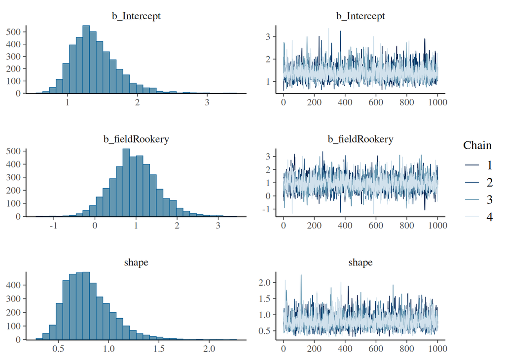

```r
plot(fit.slugs.nb)
```

We have a small $\tau$, so the data is really overdispersed.

Posterior predictions

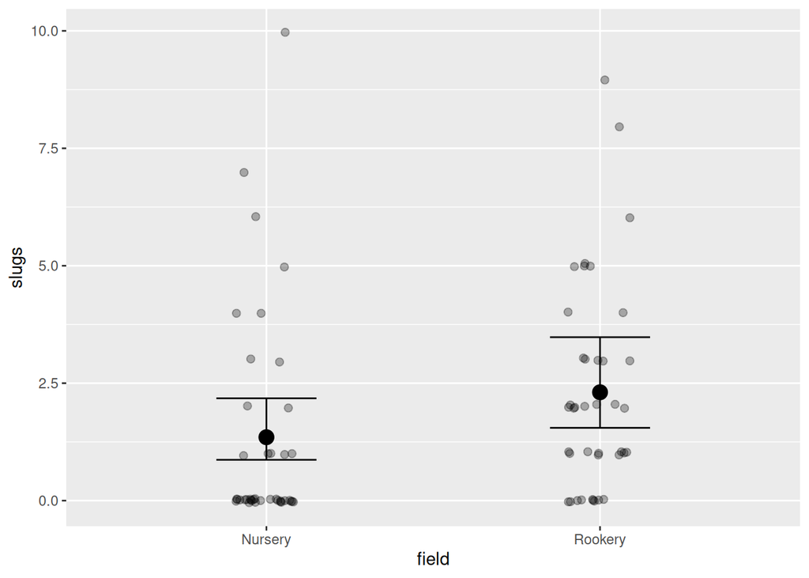

```r
plot(conditional_effects(fit.slugs.nb),
     points=T,
     point_args=list(alpha=0.3, width=0.1, height=0.05)
)
```

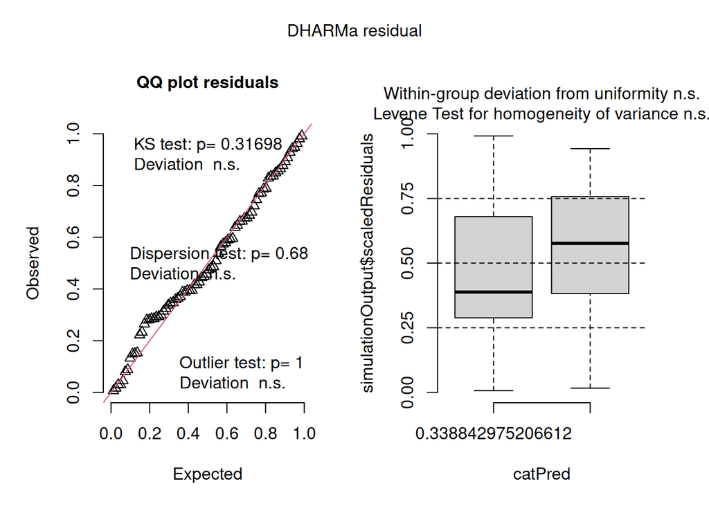

```r
dh_check_brms(fit.slugs.nb) # DHARMa
```

The distributional assumptions are OK now.

```r
LOO(fit.slugs, fit.slugs.nb)
```

```
             elpd_diff se_diff
fit.slugs.nb   0.0       0.0
fit.slugs    -29.7      11.2
```

Model comparison also tells us that the Negative Binomial is more appropriate.

```r
fixef(fit.slugs) |> round(3)
```

```
             Estimate Est.Error  Q2.5 Q97.5
Intercept       1.307     0.182 0.967 1.689
fieldRookery    0.977     0.295 0.409 1.559
```

```r
fixef(fit.slugs.nb) |> round(3)
```

```
             Estimate Est.Error   Q2.5 Q97.5
Intercept       1.394     0.331  0.869 2.178
fieldRookery    0.965     0.573 -0.091 2.153
```

The effect size (difference in group-means) has a larger standard deviation in the Negative Binomial. In different words: we would have been overly confident about the effect size in the Poisson model.

```r
hypothesis(fit.slugs, "fieldRookery>0")
```

```
Hypothesis Tests for class b:
          Hypothesis Estimate Est.Error CI.Lower CI.Upper Evid.Ratio Post.Prob Star
1 (fieldRookery) > 0     0.98      0.29     0.49     1.46       1999         1    *
---
'CI': 90%-CI for one-sided and 95%-CI for two-sided hypotheses.
'*': For one-sided hypotheses, the posterior probability exceeds 95%;
for two-sided hypotheses, the value tested against lies outside the 95%-CI.
Posterior probabilities of point hypotheses assume equal prior probabilities.
```

```r
hypothesis(fit.slugs.nb, "fieldRookery>0")
```

```
Hypothesis Tests for class b:
          Hypothesis Estimate Est.Error CI.Lower CI.Upper Evid.Ratio Post.Prob Star
1 (fieldRookery) > 0     0.97      0.57     0.07     1.94      24.97      0.96    *
---
'CI': 90%-CI for one-sided and 95%-CI for two-sided hypotheses.
'*': For one-sided hypotheses, the posterior probability exceeds 95%;
for two-sided hypotheses, the value tested against lies outside the 95%-CI.
Posterior probabilities of point hypotheses assume equal prior probabilities.
```

**Always consider overdispersion in count data. Poisson results can be misleading.**

# Binomial regression

This experiment is about mice infected with parasites of the genus Cryptosporidium. Each replicate has a certain number of mice inoculated by some Dose of parasite oocysts. Then the number of infected mice is counted. (from Quian (2016) Environmental and Ecological Statistics with R)

Fit a dose-response model.

**Question:** What minimum parasite dose is required to infect at least 75% of a mouse population?

Deterministic part: $\text{logit}(\mu)=a+b\cdot Dose$  
Stochastic part: $Y_{infected} \sim \text{Binomial}(Y_{inoculated},\mu)$

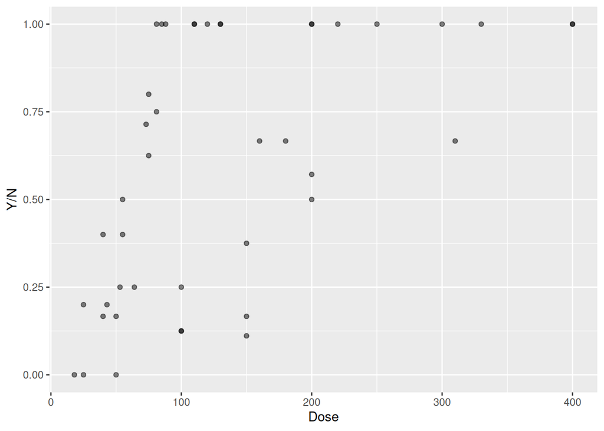

```r
df = read.csv("https://raw.githubusercontent.com/songsqian/eesR/refs/heads/master/R/Data/cryptoDATA.csv",
              sep=" ")
df.sub = subset(df, Source=="Finch")
df.sub$Y = as.integer(df.sub$Y)
ggplot(df.sub, aes(Dose, Y/N)) + geom_point(alpha=0.5)
```

Again, we want to scale the predictor `Dose`. Here, we directly write `scale(Dose)` in the model formula. The advantage is that priors and parameters on z-scale, but plots / conditional_effects are on original scale.

```r
default_prior(Y | trials(N) ~ scale(Dose),
              family = binomial(link=logit),
              data = df.sub )
```

```
                prior     class      coef group resp dpar nlpar lb ub tag       source
               (flat)         b                                                default
               (flat)         b scaleDose                                 (vectorized)
 student_t(3, 0, 2.5) Intercept                                                default
```

We add a weakly informative prior on the (linear scale) slope. The effect is expected to be positive.

```r
fit.crypto = brm(Y | trials(N) ~ scale(Dose),
                 family = binomial(link=logit),
                 prior = prior(normal(1,1), class=b),
                 data = df.sub )
```

Check convergence

```r
summary(fit.crypto, prior=T)
```

```
 Family: binomial
  Links: mu = logit
Formula: Y | trials(N) ~ scale(Dose)
   Data: df.sub (Number of observations: 43)
  Draws: 4 chains, each with iter = 2000; warmup = 1000; thin = 1;
         total post-warmup draws = 4000

Priors:
b ~ normal(1, 1)
Intercept ~ student_t(3, 0, 2.5)

Regression Coefficients:
          Estimate Est.Error l-95% CI u-95% CI Rhat Bulk_ESS Tail_ESS
Intercept     0.41      0.14     0.14     0.69 1.00     2681     2445
scaleDose     1.22      0.19     0.87     1.62 1.00     2458     2436

Draws were sampled using sampling(NUTS). For each parameter, Bulk_ESS
and Tail_ESS are effective sample size measures, and Rhat is the potential
scale reduction factor on split chains (at convergence, Rhat = 1).
```

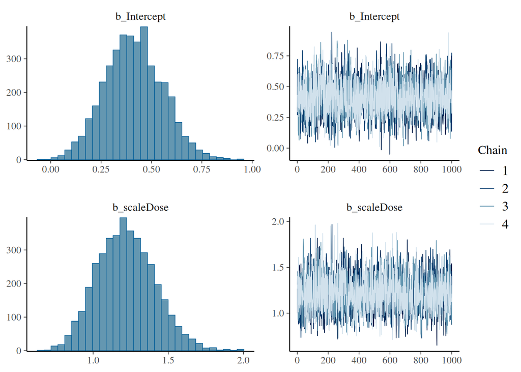

```r
plot(fit.crypto)
```

`conditional_effects()` plots predictions for N=1 trials only. `points=TRUE` just adds Y values, but we need Y/N values!

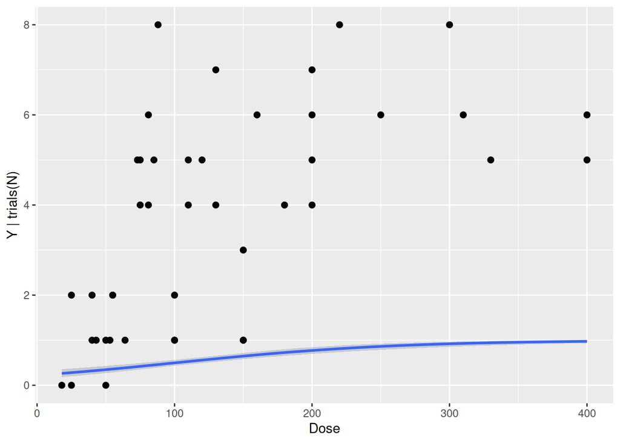

```r
plot(conditional_effects(fit.crypto, effects="Dose"), points=TRUE)
```

Some ggplot-tricks to the rescue!! Note that `conditional_effects()` now plots everything on the predictor’s original scale, not on the z-scale.

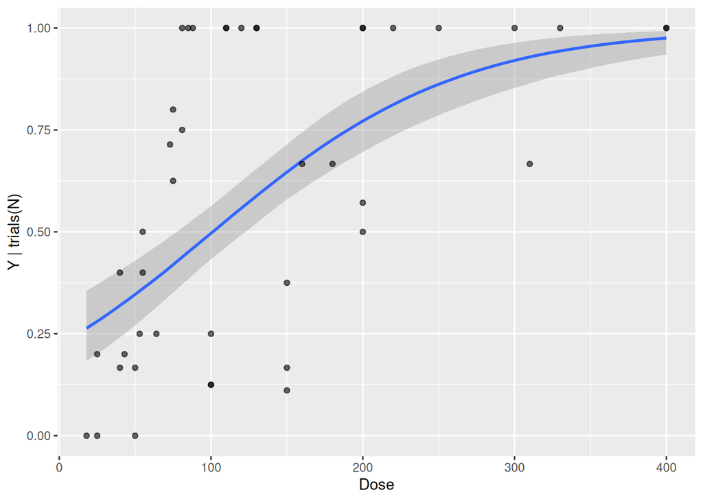

```r
p1 = plot(conditional_effects(fit.crypto, effects="Dose"),
          points=FALSE, plot=FALSE)
p1[[1]] + geom_point(data=df.sub,
                     aes(Dose, Y/N),
                     alpha=0.6, size=1.5,
                     inherit.aes=FALSE)
```

Posterior predictive checks are not very pretty, but we didn’t measure any other predictors to improve it.

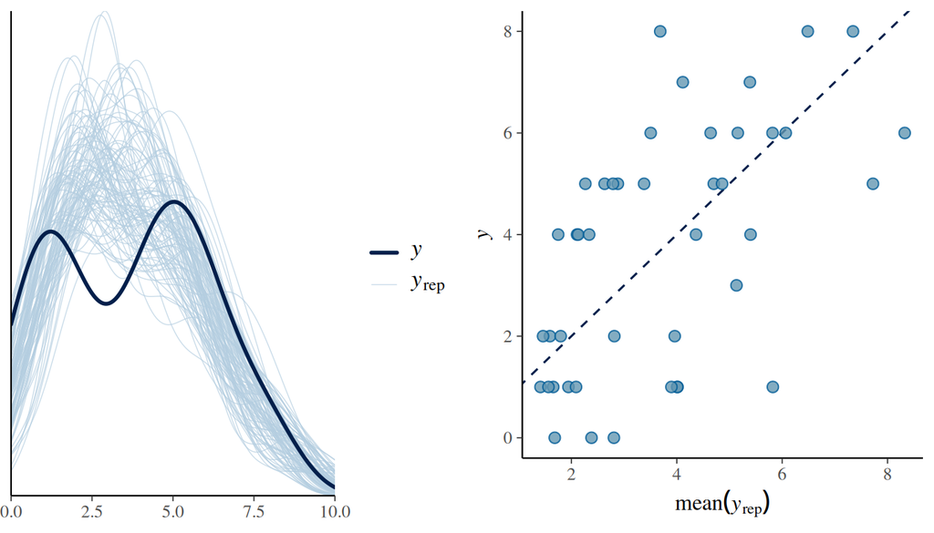

```r
p1 = pp_check(fit.crypto, ndraws=100)
p2 = pp_check(fit.crypto, type="scatter_avg")
plot_grid(p1,p2)
```

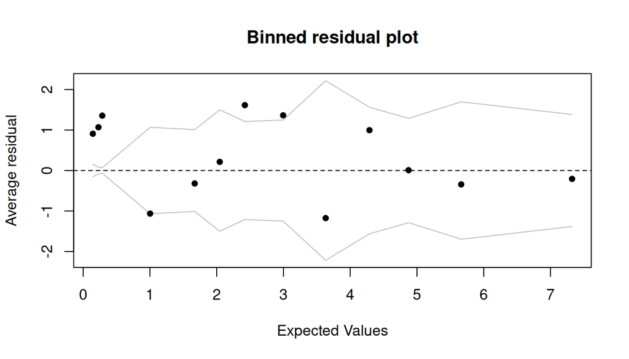

```r
fitted = fitted(fit.crypto)
residuals = residuals(fit.crypto)
binnedplot(fitted, residuals)
```

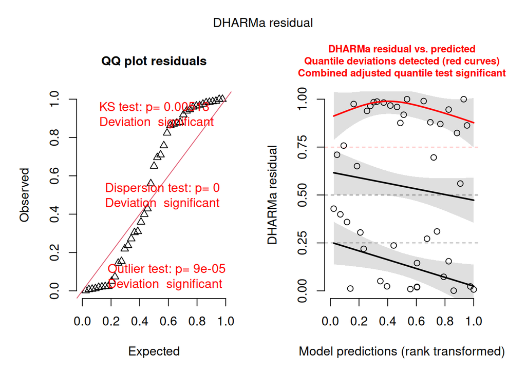

```r
dh_check_brms(fit.crypto)
```

Binomial distribution does not capture the variation observed in the data. **You could try for yourself if the Beta Binomial does a better job.** It can handle overdispersion in bounded count data. Just replace `family=binomial()` by `family=beta_binomial()`.

Back to the question: What minimum parasite dose is needed to get at least 75% of mice infected?

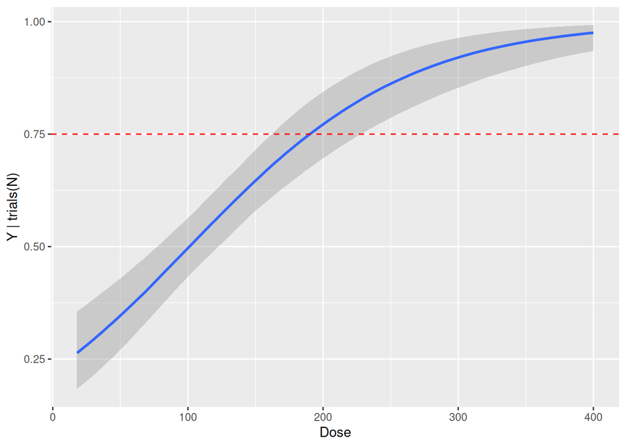

```r
p1 = plot(conditional_effects(fit.crypto, effects="Dose"),
          points=FALSE, plot=FALSE)
p1[[1]] + geom_hline(yintercept=0.75, linetype=2, col="red")
```

For Dose=191, the mean regression curve crosses the 75%-infected line, **on average** 75% are infected. But this means that we are **only 50% certain** that at least 75% are infected, $P(\mu>0.75)\approx0.5$.

```r
fitted(fit.crypto,
       newdata = data.frame(Dose=191, N=1))
```

```
      Estimate  Est.Error      Q2.5     Q97.5
[1,] 0.7510085 0.03806223 0.6768184 0.8247978
```

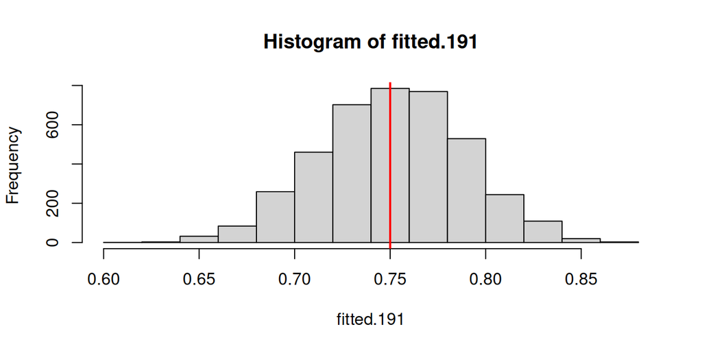

```r
fitted.191 = fitted(fit.crypto,
                    newdata = data.frame(Dose=191, N=1),
                    summary=FALSE)
hist(fitted.191)
abline(v=0.75, col="red", lwd=2)
```

Rather, we’d have to supply a dose where the 75%-line crosses the fitted lower quantile (Q2.5), which happens around Dose=229. Then we are 97.5% certain that at least 75% of mice are infected, $P(\mu>0.75)=0.975$.

```r
fitted(fit.crypto,
       newdata=data.frame(Dose=229, N=1),
       probs=0.025)
```

```
      Estimate  Est.Error      Q2.5
[1,] 0.8267238 0.03742115 0.7518593
```

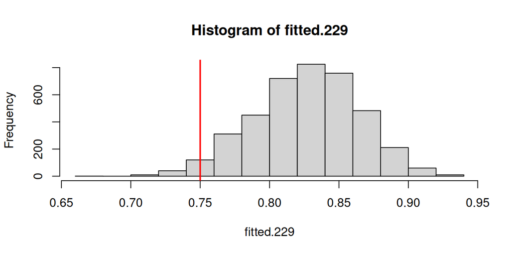

```r
fitted.229 = fitted(fit.crypto,
                    newdata = data.frame(Dose=229, N=1),
                    summary=FALSE)
hist(fitted.229)
abline(v=0.75, col="red", lwd=2)
```

# Distributional model

We model the daily growth of young chicken (from datasets package). We use only the early exponential growth phase (looks linear on the logscale). Later, growth slows down and the nonlinear Von Bertalanffy growth function is more appropriate.

**Question:** What is the daily growth rate?

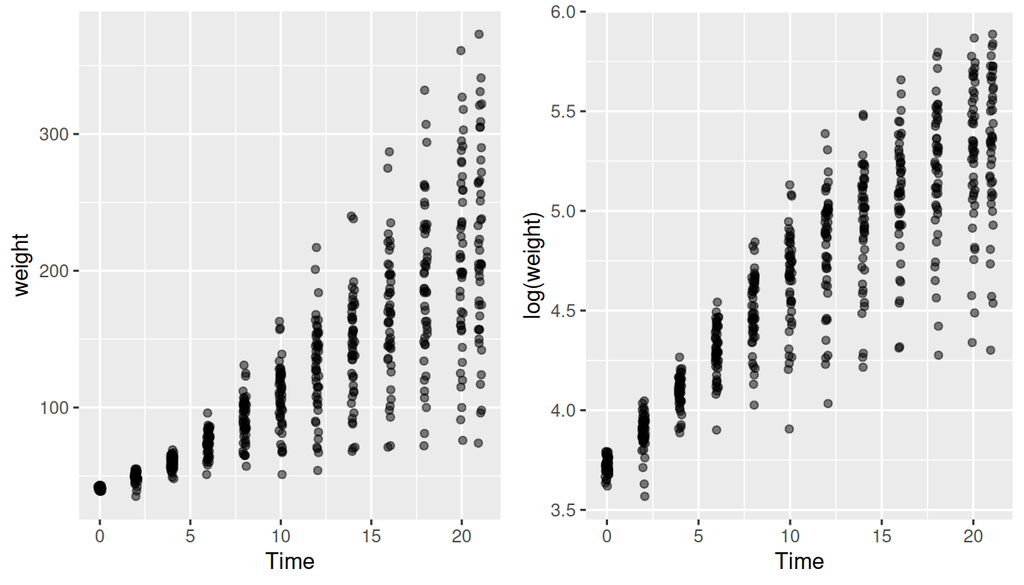

```r
data(ChickWeight)
p1 = ggplot(ChickWeight, aes(Time, weight)) +
  geom_jitter(alpha=0.5, width=0.1, height=0.05)
p2 = ggplot(ChickWeight, aes(Time, log(weight))) +
  geom_jitter(alpha=0.5, width=0.1, height=0.05)
plot_grid(p1,p2)
```

```r
ChickWeight = subset(ChickWeight, Time<15)
```

We treat the response as a continuous variable. We want to perform a simple linear regression on log(weight) first.

Deterministic part: $\mu=a+b\cdot time$  
Stochastic part: $log.weight \sim \text{Normal}(\mu,\sigma)$

```r
fit.growth.1 = brm(log(weight) ~ Time,
                   prior = prior(normal(0,1), class=b),
                   data = ChickWeight)
```

We see that prediction intervals don’t represent the variance of data well.

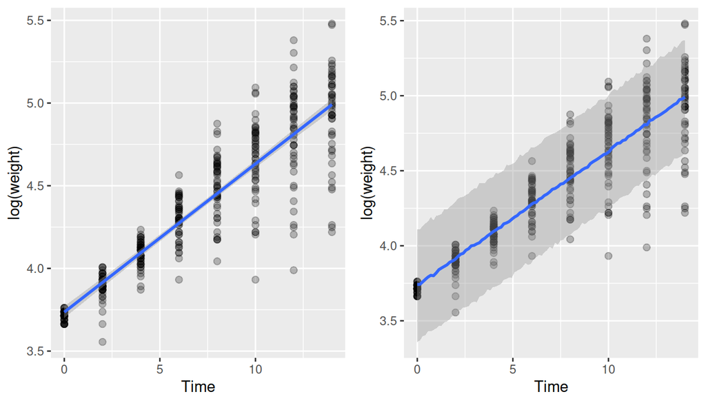

```r
p1 = plot(conditional_effects(fit.growth.1),
          points=T,
          point_args=list(alpha=0.25),
          plot=F)
p2 = plot(conditional_effects(fit.growth.1, method="posterior_predict"),
          points=T,
          point_args=list(alpha=0.25),
          plot=F)
plot_grid(p1[[1]],p2[[1]])
```

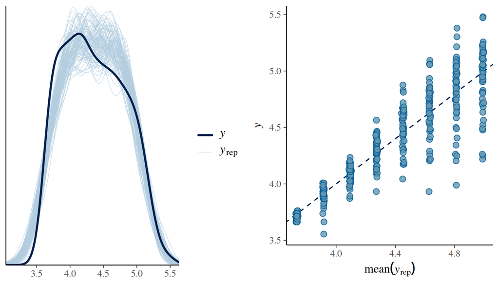

```r
p1 = pp_check(fit.growth.1, ndraws=100)
p2 = pp_check(fit.growth.1, type="scatter_avg")
plot_grid(p1,p2)
```

Linear model assumptions are not satisfied, especially the homogeneity of variance.

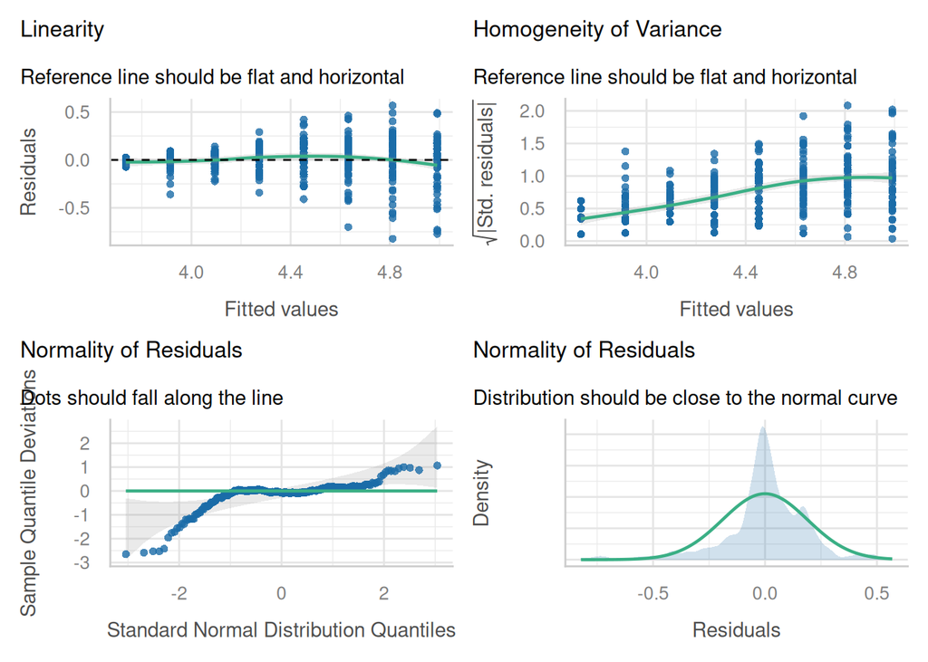

```r
check_model(fit.growth.1, check=c("linearity","homogeneity","qq","normality"))
```

We introduce a **distributional model**, where not only $\mu$, but also $\sigma$ is a function of the predictor $time$.

Deterministic part: $\mu=a+b\cdot time$  
$\log(\sigma) = c + d \cdot time$ (log-link to keep $\sigma>0$)  
Stochastic part: $log.weight \sim \text{Normal}(\mu,\sigma)$

Both model parts for $\mu$ and $\sigma$ are combined with `bf()` (short for brmsformula). For sigma, the log-link is provided automatically

```r
default_prior(bf(log(weight) ~ Time,
                 sigma ~ Time),
              data = ChickWeight)
```

```
                  prior     class coef group resp  dpar nlpar lb ub tag       source
                 (flat)         b                                            default
                 (flat)         b Time                                  (vectorized)
 student_t(3, 4.3, 2.5) Intercept                                            default
                 (flat)         b                 sigma                      default
                 (flat)         b Time            sigma                 (vectorized)
   student_t(3, 0, 2.5) Intercept                 sigma                      default
```

We provide weak priors for both effects (slope for $\mu$ and $\sigma$ with time)

```r
fit.growth.2 = brm(bf(log(weight) ~ Time,
                      sigma ~ Time),
                   prior =
                     prior(normal(0,1), class=b, coef=Time) +
                     prior(normal(0,1), class=b, dpar=sigma),
                   data = ChickWeight)
```

Check convergence

```r
summary(fit.growth.2, prior=T)
```

```
 Family: gaussian
  Links: mu = identity; sigma = log
Formula: log(weight) ~ Time
         sigma ~ Time
   Data: ChickWeight (Number of observations: 393)
  Draws: 4 chains, each with iter = 2000; warmup = 1000; thin = 1;
         total post-warmup draws = 4000

Priors:
b_Time ~ normal(0, 1)
b_sigma ~ normal(0, 1)
Intercept ~ student_t(3, 4.3, 2.5)
Intercept_sigma ~ student_t(3, 0, 2.5)

Regression Coefficients:
                Estimate Est.Error l-95% CI u-95% CI Rhat Bulk_ESS Tail_ESS
Intercept           3.71      0.01     3.70     3.72 1.00     4798     3233
sigma_Intercept    -3.06      0.07    -3.20    -2.92 1.00     3186     2369
Time                0.09      0.00     0.09     0.10 1.00     3053     2660
sigma_Time          0.15      0.01     0.14     0.17 1.00     3279     2646

Draws were sampled using sampling(NUTS). For each parameter, Bulk_ESS
and Tail_ESS are effective sample size measures, and Rhat is the potential
scale reduction factor on split chains (at convergence, Rhat = 1).
```

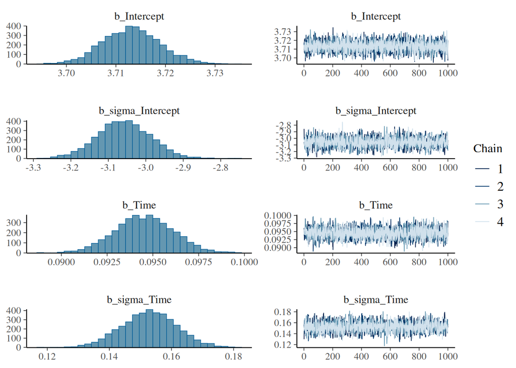

```r
plot(fit.growth.2)
```

Posterior predictions are looking much better now. We don’t use the `check_model()` here, because it’s not a linear model anymore.

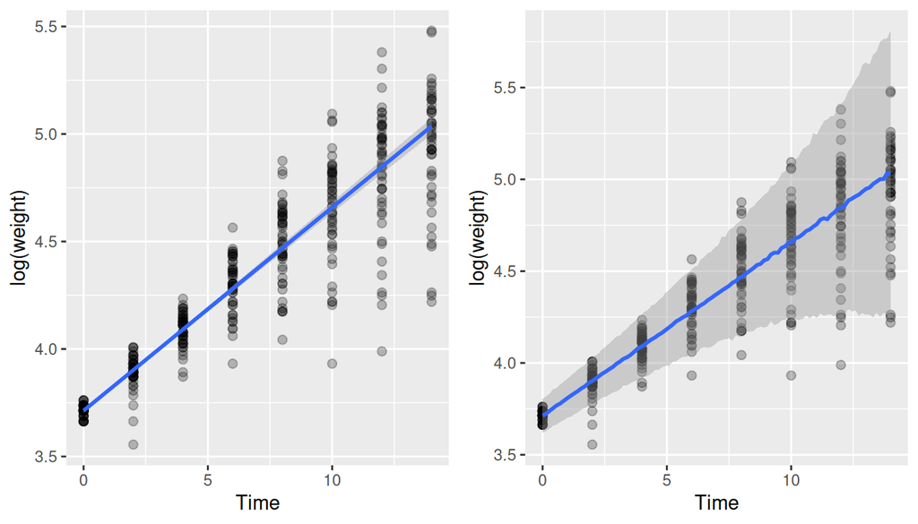

```r
p1 = plot(conditional_effects(fit.growth.2),
          points=T,
          point_args=list(alpha=0.25),
          plot=F)
p2 = plot(conditional_effects(fit.growth.2, method="posterior_predict"),
          points=T,
          point_args=list(alpha=0.25),
          plot=F)
plot_grid(p1[[1]],p2[[1]])
```

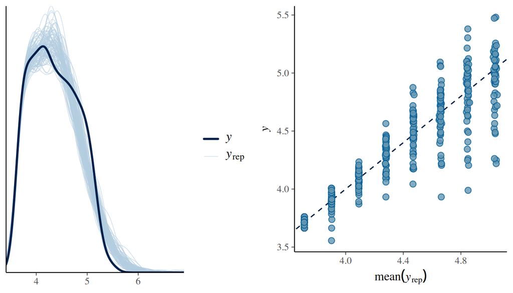

```r
p1 = pp_check(fit.growth.2, ndraws=100)
p2 = pp_check(fit.growth.2, type="scatter_avg")
plot_grid(p1,p2)
```

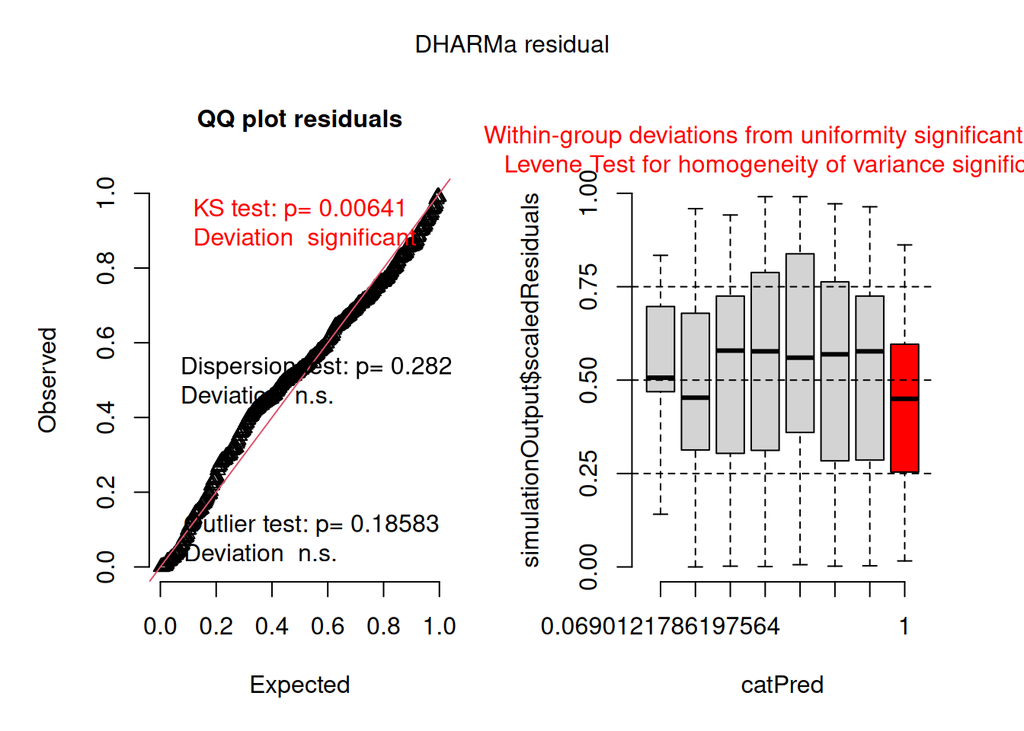

```r
dh_check_brms(fit.growth.2) # DHARMa
```

DHARMa checks are not perfect, but model comparison reveals that the distributional model is preferred.

```r
LOO(fit.growth.1, fit.growth.2)
```

```
             elpd_diff se_diff
fit.growth.2    0.0       0.0
fit.growth.1 -131.1      22.3
```

**Question:** What is the average daily growth rate?

$\log(weight)=a+b\cdot time$ –> $weight=\exp(a)\cdot \exp(b)^{time}$

$\exp(b)$ is average daily growth rate, but we must use the whole posterior distribution! Don’t just use mean $\bar b$ and compute $\exp(\bar b)$. Jensen’s inequality says you might get a biased value with nonlinear parameter transformations!

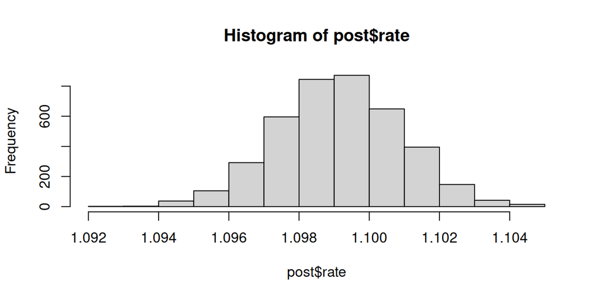

```r
post = as_draws_df(fit.growth.2)
post$rate = exp(post$b_Time)
hist(post$rate)
```

```r
mean(post$rate)
```

```
[1] 1.099137
```

```r
quantile(post$rate, prob=c(0.05, 0.95))
```

```
      5%      95%
1.096223 1.102011
```

The daily growth rate is 1.099, this means an 9.9% increase every day.

**Alternative:** The distributional model automatically used a log-link on `sigma` to keep it positive. Caveat: `sigma` increases exponentially with predictor `time`. To model a linear increase, we can drop the log-link and use an identity-link instead. But we have to ensure positiveness, otherwise the model will likely crash. Here, we use positive boundaries on `sigma`’s intercept and slope.

Deterministic part: $\mu=a+b\cdot time$  
$\sigma = c + d \cdot time$ (no log-link)  
$c,d>0$ (to keep $\sigma>0$)  
Stochastic part: $log.weight \sim \text{Normal}(\mu,\sigma)$

```r
fit.growth.3 = brm(bf(log(weight) ~ Time,
                      sigma ~ Time),
                   family = brmsfamily("gaussian", link_sigma = "identity"),
                   prior =
                     prior(normal(0,1), class=b, coef=Time) +
                     prior(normal(0,1), class=Intercept, dpar=sigma, lb=0) +
                     prior(normal(0,1), class=b, dpar=sigma, lb=0),
                   data = ChickWeight)
```

Try for yourself!

# Exercise: Logistic regression

From Qian, S. (2016) Environmental and Ecological Statistics with R

This field experiment is about seed predation by rodents (response $Predation=\{0,1\}$). Seeds were placed in gauze bags in 4 topographic locations (predictor $topo$). Sites were visited in 6 sampling campaigns (predictor $time$). Also control for continuous predictor $seed.weight$.

Deterministic part: $\text{logit}(\mu)=\dots$  
Stochastic part: $Predation \sim \text{Bernoulli}(\mu)$

1. Start with `Predation~log(seed.weight)`
2. Test if there is a difference between locations (`+topo`)
3. Also use time as factorial predictor (`+time`)

**Question:** Does predation rate reach a stable value in the last three time periods?

Hint: Use `emmeans` for predicting average predation rates for all the different levels of `time` and also their contrasts.

```r
df = read.csv("https://raw.githubusercontent.com/songsqian/eesR/refs/heads/master/R/Data/seedbank.csv",
              sep=",")
df = subset(df, Predation %in% 0:1)
df$Predation = as.integer(df$Predation)
df$time = as.factor(df$time)
df$topo = as.factor(df$topo)
df$seed = scale(log(df$seed.weight))
head(df)
```

```
  species seed.weight time topo ground Predation        seed
1       8      4250.0    3    1      2         0  2.10606568
2       5        28.5    1    1      2         0  0.01142359
3       5        28.5    3    1      2         0  0.01142359
4       2         4.5    1    1      2         0 -0.76110864
5       2         4.5    2    1      2         0 -0.76110864
6       2         4.5    3    1      2         0 -0.76110864
```

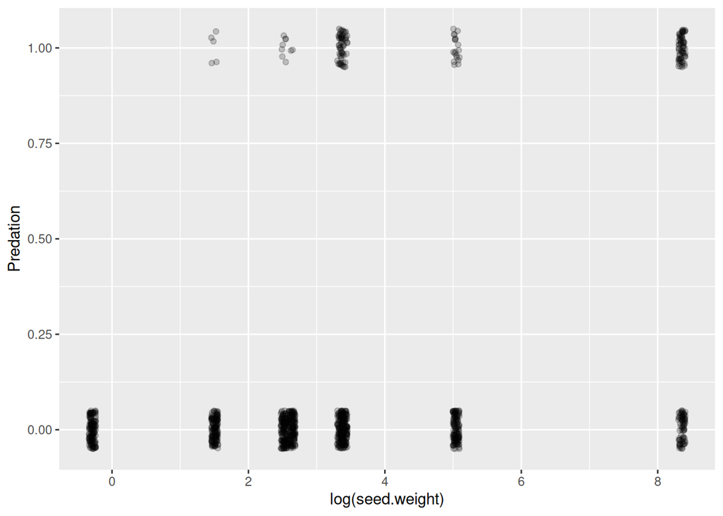

```r
ggplot(df, aes(log(seed.weight), Predation)) +
  geom_jitter(height=0.05, width=0.05, alpha=0.2)
```

## Model 1

We start with a simple logistic regression, just with the continuous predictor `seed`. Note that priors for intercept and slope are on linear scale ($\eta$ in the lecture), not on response scale ($\mu$ in the lecture).

```r
df.seed.1 = brm(Predation ~ seed,
                family = bernoulli(link=logit),
                prior = prior(normal(1,1), class=b),
                data = df )
```

Check convergence

```r
summary(df.seed.1, prior=T)
```

```
 Family: bernoulli
  Links: mu = logit
Formula: Predation ~ seed
   Data: df (Number of observations: 1142)
  Draws: 4 chains, each with iter = 2000; warmup = 1000; thin = 1;
         total post-warmup draws = 4000

Priors:
b ~ normal(1, 1)
Intercept ~ student_t(3, 0, 2.5)

Regression Coefficients:
          Estimate Est.Error l-95% CI u-95% CI Rhat Bulk_ESS Tail_ESS
Intercept    -2.14      0.11    -2.35    -1.93 1.00     1743     2201
seed          1.02      0.09     0.86     1.19 1.00     1876     2271

Draws were sampled using sampling(NUTS). For each parameter, Bulk_ESS
and Tail_ESS are effective sample size measures, and Rhat is the potential
scale reduction factor on split chains (at convergence, Rhat = 1).
```

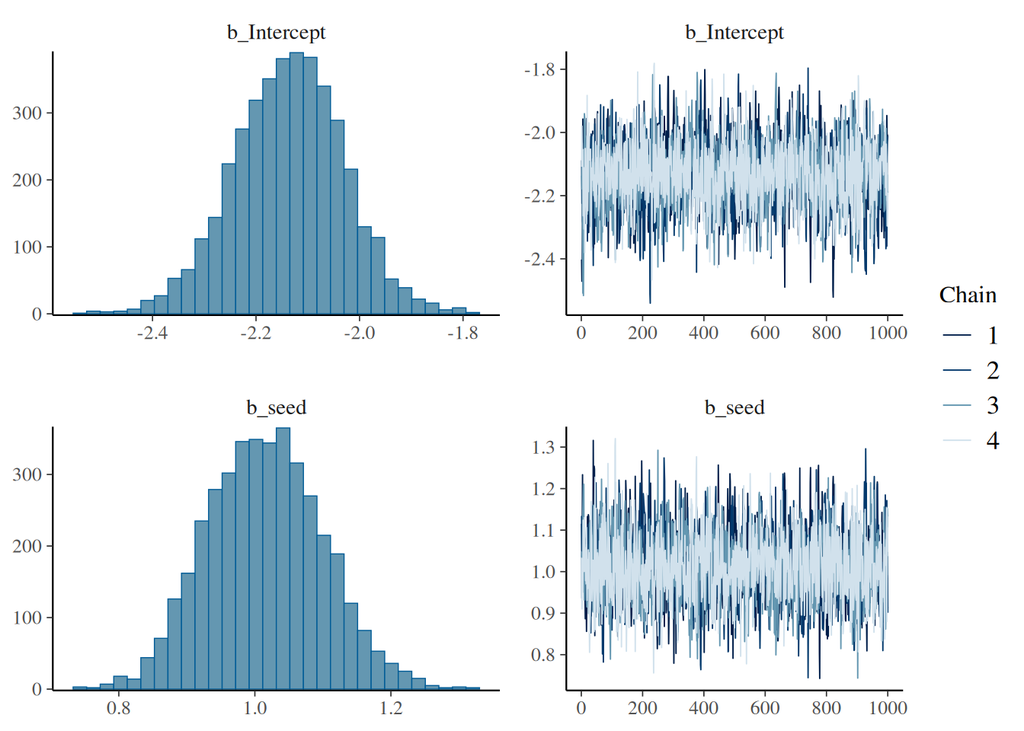

```r
plot(df.seed.1)
```

Posterior predictive checks

```
Ignoring unknown labels:
• fill : "NA"
• colour : "NA"
Ignoring unknown labels:
• fill : "NA"
• colour : "NA"
```

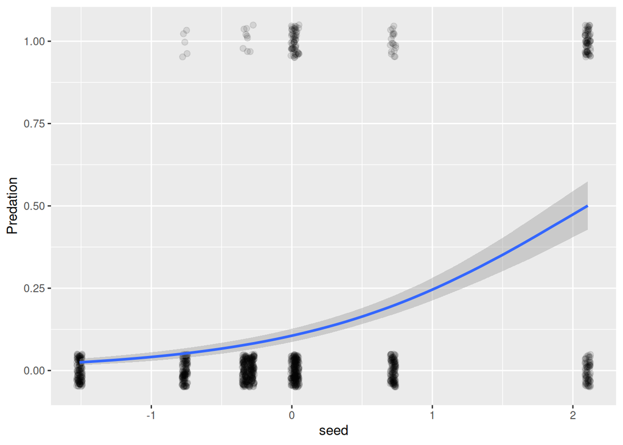

```r
plot(conditional_effects(df.seed.1),
     points = T,
     point_args = list(alpha=0.1, width=0.02, height=0.05)
)
```

DHARMa checks look fine, just some small deviations in the residuals. We are adding more predictors and hope this will solve it.

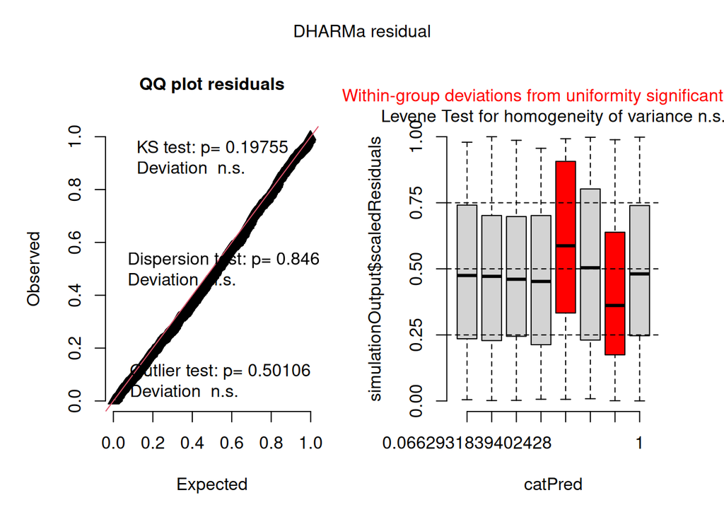

```r
dh_check_brms(df.seed.1)
```